# Notebook 3: Erosion and Sediment Transport

June 30, 2022

# Fundamentals of Hydrology: Erosion and Sediment Transport

## Introduction

### Erosion and sediment transport

**Question**: What is erosion, and how is it related to sediment transport in streams?

**Question**: How is particulate material supplied to stream channels in mountainous headwater streams?

Today, we are going to explore suspended sediment data. These data span several decades and are part of a Long Term Ecological Research Forest in Oregon. The [H.J.Andrews LTER](https://andrewsforest.oregonstate.edu/) is located in the Oregon Cascades. But before looking at these data, we need to load some packages that we installed in the previous session

We will use the same data set analyzed in the stream flow section.

**To do**: Visit the [H.J.Andrews LTER](https://andrewsforest.oregonstate.edu/) website and find the appropriate form the data set used in our class.

In this dataset, Total Suspended Solids (TSS) is represented by the variable “sed.mg_l” in which mg_l is the concentration unit (miligrams per litter). Let’s start with a quick look of the time series:

### Suspended sediments over time

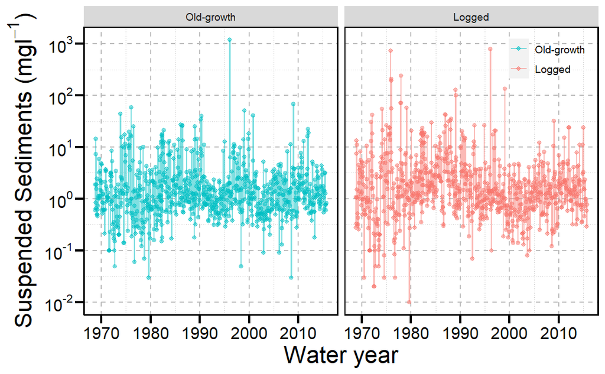

*To do*: Add a caption to the figure and describe the changes observed over time.

### Suspended sediment concentrations along the hydrological year (Oct 1 - Sept 30)

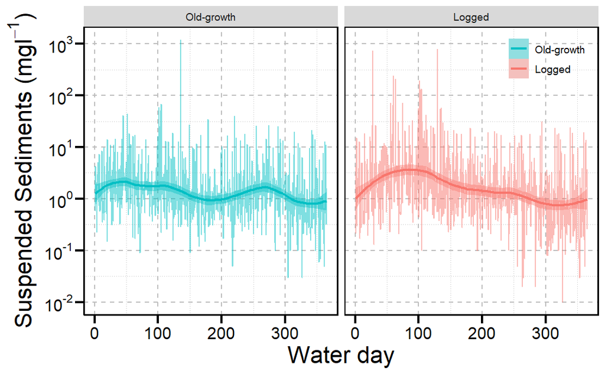

*To do*: Add a caption to the figure and describe the changes observed over time.

### Distribution of TSS concentrations in and Old-growth and logged watershed in the Oregon Cascades

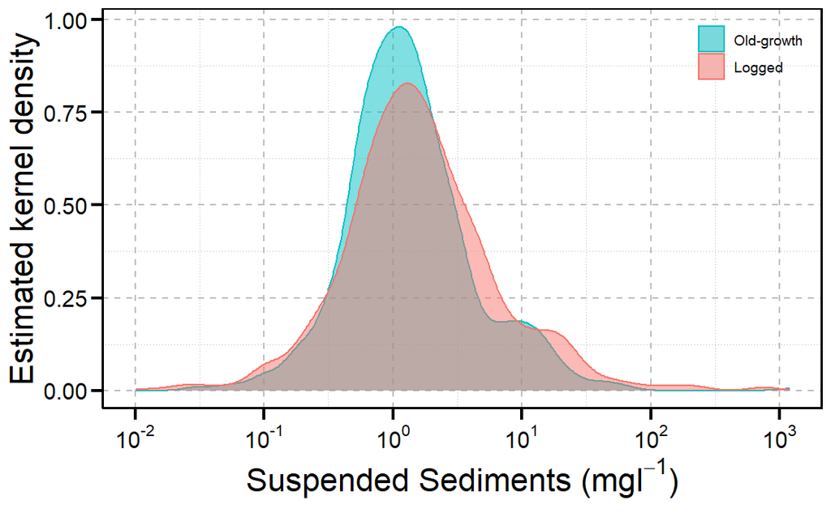

*To do*: add a caption to the figure and compare the density distribution of TSS concentrations between watersheds.

### Seasonal changes in the distribution of TSS concentrations in and Old-growth and logged watershed in the Oregon Cascades

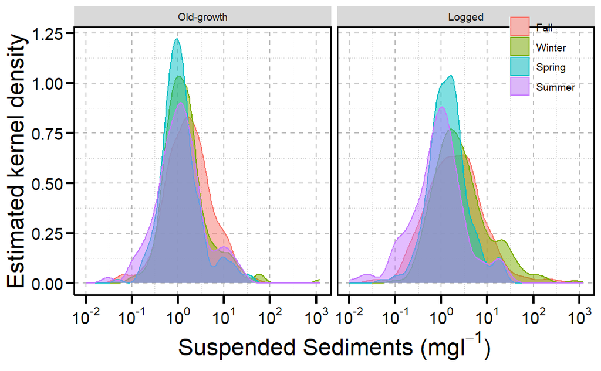

Let’s compare both watersheds season by season

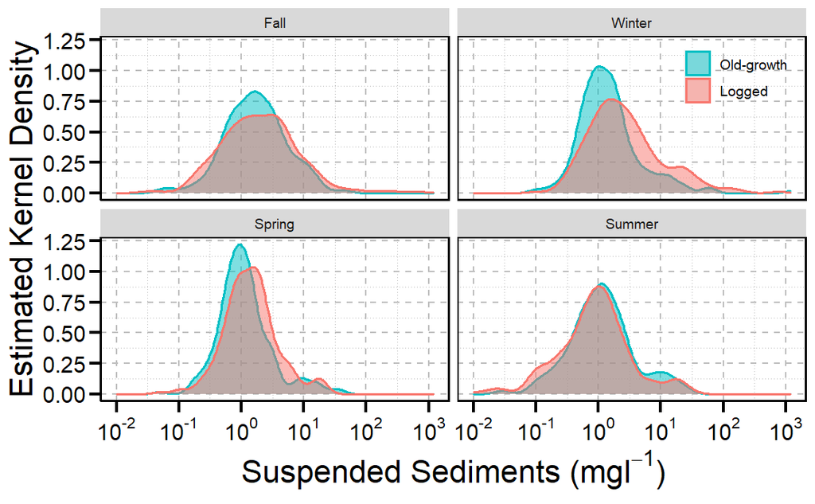

*To do*: add a caption to the figure and compare the density distribution of TSS concentrations between watersheds.

### Temporal evolution in the Suspended sediment load in heawater streams in the Oregon Cascades

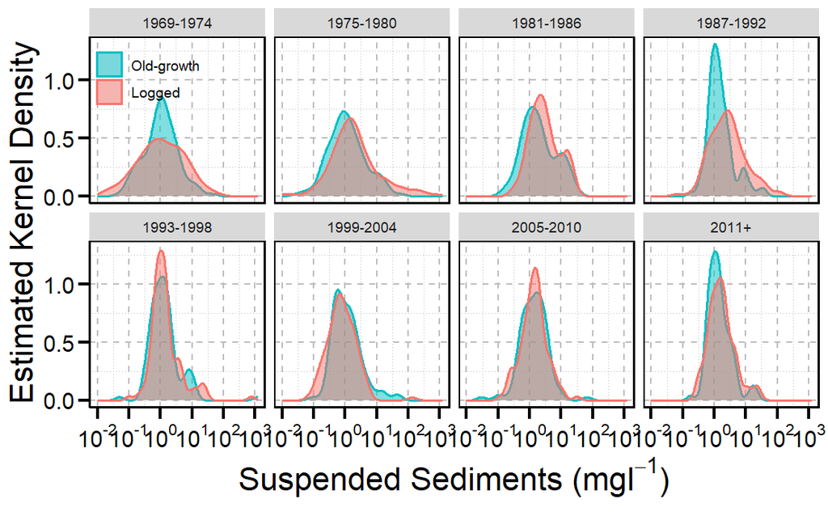

Let’s take a similar look at discharge data:

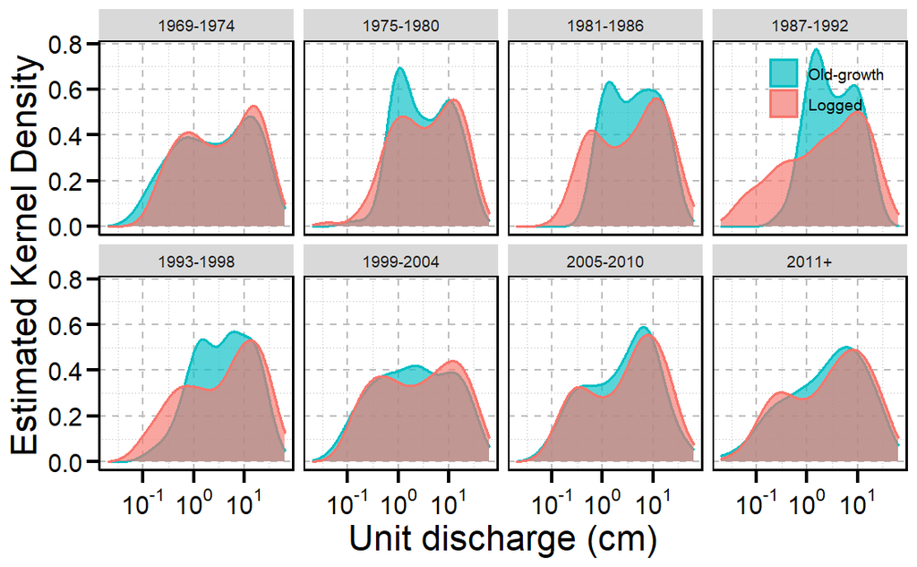

Let’s now calculate sediment load:

```r
 hjs$sed_kg_ha <- (hjs$uq.cm * hjs$sed.mg_l)/10
```

Finally, let’s take a look at the temporal evolution of the sediment load:

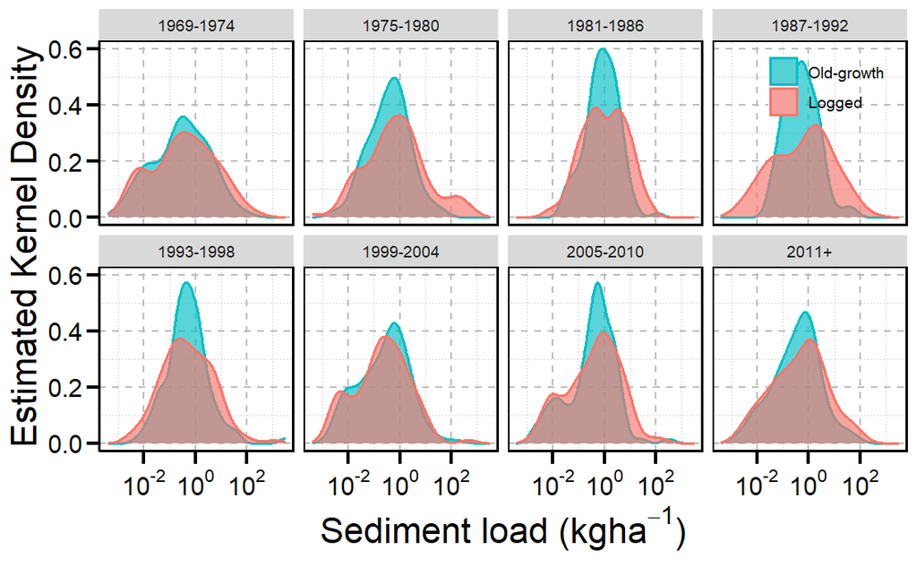

*To do*: add a caption to the figure and compare the density distribution of Sediment loads between watersheds and across time periods.